# The canon of decision-making trade-offs across domains

By: Andrew McKenzie

Date: First Published: 2010-07-10; Last Major Update: 2023-01-08

- [Link back to the home page](https://andrewtmckenzie.com/)

### Introduction

Most of the time, when we make decisions, we don’t bother thinking about the trade-offs involved. Instead, we focus on the details of the particular decision we have to make. Meta-level reasoning is time-consuming and taxing, so most of the time, this is the best strategy. Then why think at all about decisions at the more abstract, trade-off level? I offer a few reasons:

First, it can lend clarity to the types of parameters that we might want to consider when we do reason explicitly. In multi-dimensional problems in particular, it can be useful to have a vocabulary to consider and discuss the most important decision axes.

Second, we can learn useful heuristics that we can apply without much explicit reasoning the next time we make a decision that involves that class of trade-off.

Third, it offers a way to organize examples so that we can more efficiently learn about how others have dealt with the types of decisions that we face.

Fourth, I think there is a psychological benefit of some kind in knowing that you are not alone in facing some of these dilemmas.

Finally, I think a broader awareness and an accepted common knowledge that *there are trade-offs* will help make policy discussions more fruitful at the local and broader scales.

I’m always on the look-out to add a) canon-worthy classes of trade-offs that are currently not subsumed by the below or b) any nice examples of examples of trade-offs within a class. If you have any thoughts, please [contact me](https://andrewtmckenzie.com/).

### #1: Efficiency vs Unpredictability

“It’s funny. All you have to do is say something nobody understands and they’ll do practically anything you want them to.” – J.D. Salinger

Upside of efficiency: achieve your goals using fewer resources

Upside of unpredictability: competitors are worse at modeling your behavior

**Major Example**

- In [Texas Hold ’Em](http://en.wikipedia.org/wiki/Texas_hold_'em), if you’d never make a large bet pre-flop with a bad hand like J3 off-suit, then your opponents can be be very sure that you do not have that hand if you make that bet. So, making an aggressive bet even with a bad hand every now and then makes it harder for your opponents to model you. This makes it easier for you to deceive them. On the other hand, there are fewer ways for a relatively worse hand to win if the betting does come to a showdown.

**Ancillary Examples**

- In [ethology](http://en.wikipedia.org/wiki/Antipredator_adaptation), consider a prey animal escaping from its predator. If the prey predictably uses the same, efficient trick to escape, it saves energy that would be spent escaping. But, its predator can learn this rule and use it for capture. For example, see a tentacled snake learn such a rule [here](http://www.youtube.com/watch?v=urBp2X5mBmQ&feature=player_embedded).
- In primate status and courtship games, individuals likely benefited from veiling their true intentions in conversation [(Miller, 1997)](https://psycnet.apa.org/record/1997-36638-011). In such a situation, deception-detection becomes advantageous as well, and one way for agents to fool others and make their mental modeling more difficult is to be unpredictable. This likely selected for some amount of randomness and thus novelty in behavior.

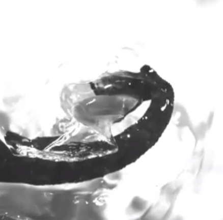

[The tentacled snake’s knowledge of its prey’s escape rule](http://www.youtube.com/watch?v=urBp2X5mBmQ&feature=player_embedded)

**Properties**

- In a competitive environment, the classic way for an agent to sacrifice efficiency for unpredictability is through adding randomness to its behavior. The key question is typically not *whether* to add randomness, but *how much* randomness to add.

### #2: Speed vs Accuracy

“Fast is fine but accuracy is final.” – Wyatt Earp

Upside to speed: less time to achieve goal

Upside to accuracy: higher probability of success in achieving goal

**Major Example**

- Like many machine learning algorithms, Watson, the AI created by IBM to compete at Jeopardy, faced a speed vs accuracy trade-off in that the longer it has to search its databases and run its algorithms, the more confidently it could assign a high probability to one of its answers.

**Ancillary Examples**

- In football, field goal (FG) kickers must contract their muscles quicker in order to swing their thighs more rapidly when they want to kick the ball further. This comes at the cost of decreased average coordination among muscle movements, because each of them must occur within a narrower window. Thus, we see a decrease in lateral accuracy of field goals as longitudinal distance increases.
- In communication, if you take longer to respond to emails, people will expect your responses to be more accurate, whereas if respond right away, their expectations will be much lower. This is because your interlocutors will intuitively recognize the trade-off you face between speed and accuracy.

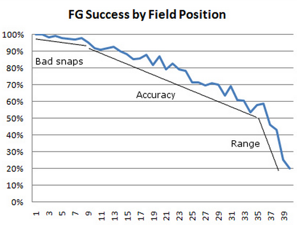

[2008 NFL Field Goal Data](http://www.advancednflstats.com/2008/11/just-for-kicks.html)

**Properties**

- Speed vs accuracy trade-offs tend to operate within particular ranges. Outside of these ranges, probabilities of success/failure theoretically should increase/decrease to 1/0. However, among humans, it is fairly common that the probability of success can paradoxically revert more towards the mean outside of this range, as people (especially non-domain experts) “overthink” their decision or action.

### #3: Exploration vs Exploitation

“Don’t get set into one form, adapt it and build your own, and let it grow; be like water.” - Bruce Lee

“I think that the minute that you have a backup plan, you’ve admitted that you’re not going to succeed.” - Elizabeth Holmes

Upside to exploration: learn more about possible choices

Upside to exploitation: gain on average more from the outcome of this particular choice

**Major Example**

- In developmental economics, you can think of basic science research as “exploration” and of applied science research as “exploitation” [(Salter et al., 2001)](http://ideas.repec.org/a/eee/respol/v30y2001i3p509-532.html). That is, investing in the search for mechanism with a relatively less clear pathway towards usefulness takes scarce resources, but probabilistically makes future applied efforts more powerful.

**Ancillary Examples**

- In [the multi-armed bandit problem](http://en.wikipedia.org/wiki/Multi-armed_bandit), a gambler is faced with multiple levers to pull from, each of which has an unknown but unique distribution of payouts. She can either sample a diverse set of levers to discover more info about their expected reward, or she can just choose the lever with the highest current expected payout.
- In organization theory, firms can “exploit” their worker’s knowledge by forcing them to socialize to their particular cultural code more quickly, but this leads to less “exploration” and ultimately a lower equilibrium knowledge level for the firm [(March, 1991)](https://www.jstor.org/stable/2634940).

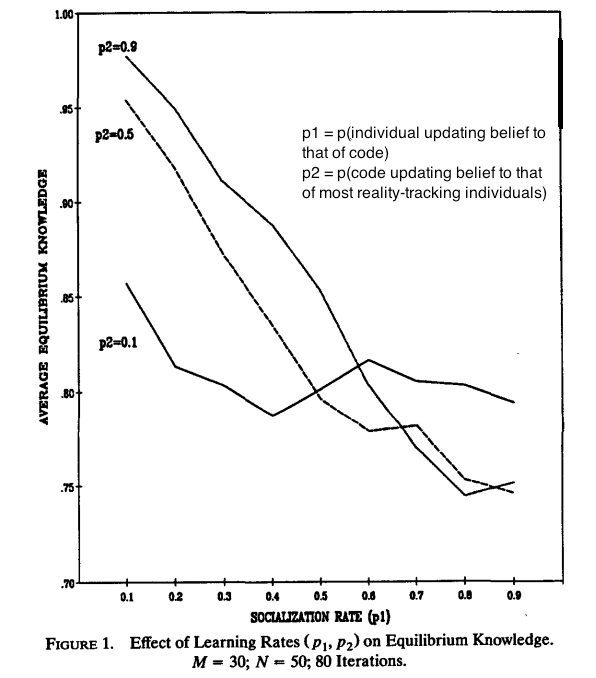

[Figure modified from March 1991 “Exploration and Exploitation in Organizational Learning”](https://www.jstor.org/stable/2634940)

**General Properties**

- As one’s initial knowledge about a topic becomes relatively worse, exploration becomes relatively more valuable relative to exploitation.
- Another way of formulating this trade-off is through the lens of [satisficing vs optimizing](http://en.wikipedia.org/wiki/Satisficing).

### #4: Precision vs Simplicity

“Plurality is never to be posited without necessity.” - [William of Occam](http://en.wikiquote.org/wiki/William_of_Occam)

Upside to precision: explain a more specific set of phenomena better

Upside to simplicity: explain a more general set of phenomena better

**Major Example**

- Imagine that you have three best friends. Two of them are kind *green aliens* and one of them is rich. You could say “I am the kind of person who could only be friends with someone who is either kind and a green alien, or rich.” But this might be overfitting your model of friendship to your current sample. Instead, it might be more appropriate to say that you could only be friends with someone who is either kind or rich.

**Ancillary Examples**

- In describing the path up to one’s apartment, one could say “there are 114 stairs,” or one could say “there are on the order of 100 stairs”; vagueness is less precise but it is also simpler and easier to communicate.
- In a [statistical regression](http://www.stat.cmu.edu/~cshalizi/uADA/12/lectures/ch04.pdf), consider building a model while varying the smoothing parameter that specifies the degree to which nearby training data points are averaged together when formulating the prediction. If you do relatively more smoothing, then your prediction will be relatively less precise in explaining the training set, but it is also simpler because it is less affected by potential outliers, so it might explain new data better.

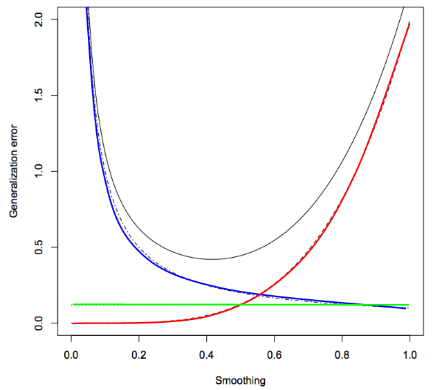

**General Properties**

- The propensity of humans to incorrectly trade-off precision and simplicity in certain contexts, like when we say that the probability of events X *and* Y is greater than the probability of just event X, is called the [conjunction fallacy](http://en.wikipedia.org/wiki/Conjunction_fallacy).

### #5: Surely Some vs Maybe More

“A bird in the hand is worth two in the bush.” - [Medieval proverb](http://www.phrases.org.uk/meanings/a-bird-in-the-hand.html)

Upside of surely some: higher probability of achieving goal state

Upside of maybe more: goal state has higher utility

**Major Example**

- In [game theory](http://en.wikipedia.org/wiki/Brinkmanship), brinkmanship is the practice of pushing competitive negotiation situations to the verge of disaster, in an attempt to induce concessions from one’s opponent. The closer towards disaster the situation is pushed, the riskier brinkmanship becomes, since the situation is more likely to truly reach disaster. On the other hand, closer to the edge often means that the expected value of concessions from one’s opponent improves, too.

**Ancillary Examples**

- In evolutionary psychology, the decision between someone who is more stable and dependable or someone with better looks and health is one of the universal trade-offs across cultures [(Shackelford et al., 2005)](http://psycnet.apa.org/psycinfo/2005-07297-020).
- In finance, [some models](http://en.wikipedia.org/wiki/Modern_portfolio_theory) suggest that investors trade-off between minimizing the variance of their portfolio and maximizing their average return. Since humans tend to have a diminishing marginal return to each additional dollar, investors are risk averse and willing to give up expected returns for a safer option.

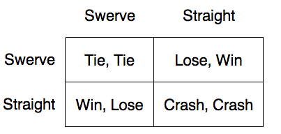

Payoff matrix for the game of chicken, the classic game of brinkmanship

**General Properties**

- Consider the case that the expected utility for both choices is the same. Then, this trade-off reduces to: what is the agent’s risk preference? If risk preference is non-neutral, then this trade-off can be relevant even when one of the choices has higher expected utility.
- In competitive environments, people often assume an efficient market and use reverse inference to conclude that if something is more difficult to attain, then it must be higher quality.

### #6: Some Now vs More Later

“Give me six hours to chop down a tree and I will spend the first four sharpening the axe.” - attributed to Abraham Lincoln

Upside to some now: get some utility right away in current state

Upside to more later: get more utility later

**Major Example**

- In sports, a common choice is made in which an individual player can either derive some value (e.g., pleasure, status, money) from *playing* a game now with one’s current skills, or one can *practice* fundamentals now, become better at the sport, and derive probabilistically more pleasure from playing later.

**Ancillary Examples**

- In developmental economics, there is an inverse correlation among children between hours of work and reading / math skills [(Akabayashi et al., 1999)](https://www.tandfonline.com/doi/abs/10.1080/00220389908422594). Children and their parents derive *some* utility now from having the children work but might derive *more* utility later if they invested more in education.
- In medicine, the health care team must often choose between making a diagnosis *early* before the appropriate lab tests have returned, in order to start treatment sooner, and making a diagnosis *later* after the lab results are back, which allows for a treatment with a higher specificity and thus higher average utility.

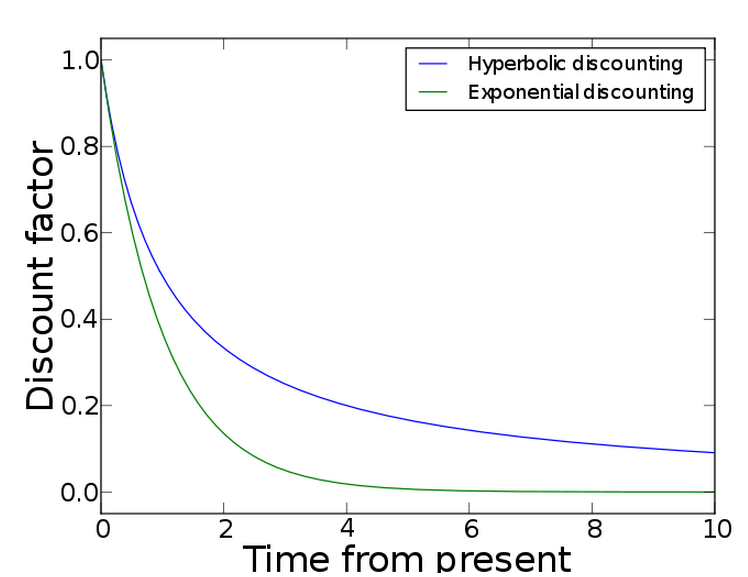

[Many elicited and stated human and other animal’s preferences follow the time-inconsistent hyperbolic pattern](https://commons.wikimedia.org/wiki/File:Hyperbolic_vs._exponential_discount_factors.svg)

**General Properties**

- Given somewhat contentious assumptions, humans and other animals often act irrationally with respect to this trade-off, tending to discount future rewards using a [hyperbolic function](http://en.wikipedia.org/wiki/Hyperbolic_discounting) rather than the mathematically consistent exponential function.

### #7: Flexibility vs Commitment

“Commitment is healthiest when it’s not without doubt, but in spite of doubt.” - Rollo May

Upside to flexibility: ability to switch more easily as knowledge or goals change

Upside to commitment: use resources on optimizing for current goal

**Major Example**

- In neuroscience, the ability of animals to flexibly alter the structure of our synaptic networks affords us a powerful ability to adapt to the reward structure of our environment. But the cost is that there is a large amount of noise generated from *non-adaptive* changes in synaptic structure. One role of sleep may be to help maintain synaptic homeostasis in the face of this noise while retaining the “important” memory traces [(Tononi et al., 2006)](http://www.ncbi.nlm.nih.gov/pubmed/16376591).

**Ancillary Examples**

- In biology, a more [evolvable](http://en.wikipedia.org/wiki/Evolvability) organism, e.g. one with a lower probability of repairing mismatched DNA base pairs during replication, will be more able to flexibly generate genetic diversity and thus switch its phenotype faster over generations via selection processes. On the other hand, this lower probability of repairing mismatched DNA will also mean that each generation that remains in the current environment will be on average less “optimized” for its current environment.
- In literature, a common choice is posed that an individual must either accept defeat in some capacity or sacrifice his or her values in order to continue. If you are more willing to sacrifice your ideals, you gain strategically, but the knowledge of this lack of commitment might make you less rigorous about working hard, insofar as it makes you more aware that you are not truly working for something larger than yourself. Plus, you won’t be achieving your original goals as directly.
- [Chesterton’s fence](https://en.wikipedia.org/wiki/Wikipedia:Chesterton%27s_fence) is a thought experiment that asks: if there is a fence in the middle of a field, and you don’t know what problem it is solving, should you remove it? By generally requiring one to find out *why* fences are in place before removing them, you increase the costs to flexibility, and thus shift the tendency of one’s actions towards commitment, which has both upsides and downsides.

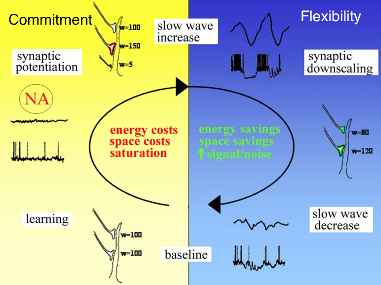

[The sleep homeostasis hypothesis by Tononi and Cerelli](http://www.ncbi.nlm.nih.gov/pubmed/16376591)

### #8: Sensitivity vs Specificity

“A: My blood test predicts cancer people with cancer 100% of the time! B: Right, but how often does it predict cancer in people without cancer?”

Upside to sensitivity: lower false negative detection rate

Upside to specificity: lower false positive detection rate

**Major Example**

- A lifeguard can choose to pay less attention to each individual momentary dip under water, and thus lower his stress from false alarms (false positives). But they inevitably do so at the risk of increasing the risk of an oversight (false negatives) – i.e., not noticing when someone is underwater for too long. When they pay more attention, they are employing a more sensitive strategy.

**Ancillary Examples**

- In [neuroscience](http://en.wikipedia.org/wiki/Mechanoreceptor), different types of mechanoreceptors have different sizes of their receptive fields – the typically oval areas of skin along which a mechanical stimulus (e.g., touch) leads to a change in that neurons action potential firing rates. In particular, Pacinian corpuscles have fairly large receptive fields, making them more sensitive (if you consider the goal of a mechanoreceptor to sense touch anywhere on the body), whereas Meissner’s corpuscles have fairly small receptive fields, making them more specific (if you consider the goal of a mechanoreceptor to detect movement only in a very small portion of the body).
- In [statistics](http://en.wikipedia.org/wiki/Receiver_operating_characteristic), a receiver operating characteristic curve allows one to show how the rates of false positives and false negatives change as you vary the threshold at which a binary classifier calls examples as either negative or positive.

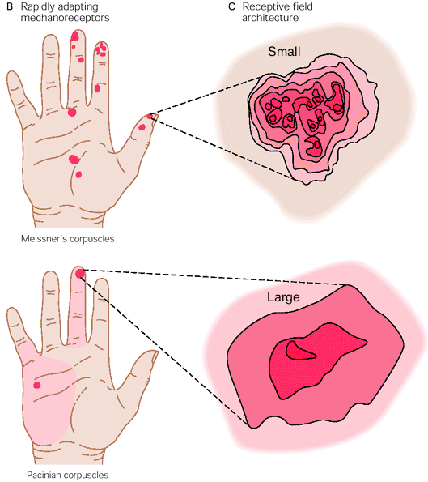

[Meissner’s mechanoreceptors have small receptive fields and thus transmit more specific information, whereas Pacinian corpuscles have larger receptive fields and thus transmit less specific information; modified from Kandel’s textbook](http://www.amazon.com/Principles-Neural-Science-Eric-Kandel/dp/0838577016)

**General Properties**

- This trade-off is so well ingrained in statistics, as the poorly-named “type 1” and “type 2” errors, that it is often applied in circumstances when it shouldn’t be. For example, people often misuse it [in an attempt to call a drug “effective” or not](http://andrewgelman.com/2015/12/14/bayesian-decision-analysis-for-the-drug-approval-process/) and doing a ROC curve analysis on related measures, rather than estimating the *continuous* effect size of a drug.

### #9: Protection vs Freedom

“The 2008 FISA amendments sought a compromise between two essential goals: preserving American liberty and robustly defending Americans’ lives and property.” - Washington Post Editorial Board

Upside to protection: lower average probability of harm from malevolent choices

Upside to freedom: more choices

**Major Example**

- When herds of prey animals are large enough, they stand a chance to fight off a given predator. Thus they tend to aggregate together, lowering their freedom but increasing the probability of their survival [(Khan et al., 2003)](http://www.ncbi.nlm.nih.gov/pubmed/12814600).

**Ancillary Examples**

- In capital-based economic systems, *work* is one way to trade freedom *now* for protection from various uncontrollable forces in the future.
- In politics, economic interventions that increase freedoms, such as organ donation markets, are typically argued against on the basis of *protecting* vulnerable individuals from *exploitation*.

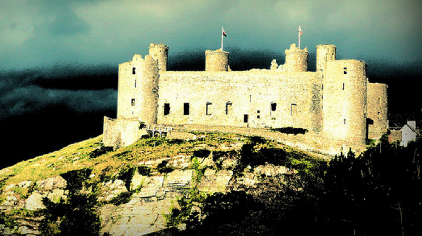

[A castle keeps others out, but it also keeps you in](http://www.flickr.com/photos/eebrierley/4115870556)

**Reversal**: This is probably the most abused trade-off. In general, just because there *could* be a trade-off between protection and freedom in a particular context does not mean that people should just accept that there *is* one. So do be wary of people who claim that freedom must be sacrificed for security without evidence.

“The whole aim of practical politics is to keep the populace alarmed (and hence clamorous to be led to safety) by an endless series of hobgoblins, most of them imaginary.” - H.L. Mencken

### #10: Loyalty vs Universality

“Duty, Honor, Country. Those three hallowed words reverently dictate what you ought to be, what you can be, what you will be.” - Douglas MacArthur

Upside to loyalty: relatively more benefits accrue to your closer, fewer associates

Upside to universality: benefits accrue further, both in geographical distance and time, and to more total sentient beings

**Major Example**

- In [evolutionary psychology](http://plato.stanford.edu/entries/altruism-biological/), the theory of kin selection explains how selfish genes can select for animals that help others, if those others are similar enough genetically. If the psychological patterns leading to kin selection are generalized to altruistic tendencies towards others in general, animals forged by natural selection can shift their mindset from loyalty to universality.

**Ancillary Examples**

- In [ethics](http://en.wikipedia.org/wiki/A_Theory_of_Justice), one theory posits that you should consider social justice principles from behind a “veil of ignorance” that obscures your own particular situation. This line of thinking is designed to shift people along the spectrum towards universalism.
- In psychology, the amount of money people are willing to pass up in order to give $75 to someone else decreases as the perceived social distance increases between them. So, humans tend to only be loyal towards a fairly limited number of people [(Jones et al., 2006)]((http://www.ncbi.nlm.nih.gov/pubmed/16623683).

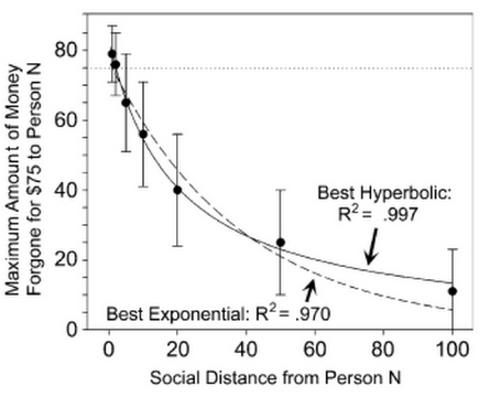

[Social discounting](http://www.ncbi.nlm.nih.gov/pubmed/16623683)

**General Properties**

- The idea that the number and types of creatures considered by the ruling classes of society to be “morally relevant” has been increasing over time is often called [The Expanding Circle](http://en.wikipedia.org/wiki/Peter_Singer#Meta-ethics_and_foundational_issues). One explanation of this trend is that morality is heavily a function of our available technology.

### #11: Saving vs Savoring

“If the world were merely seductive, that would be easy. If it were merely challenging, that would be no problem. But I arise in the morning torn between a desire to improve (or save) the world and a desire to enjoy (or savor) the world. This makes it hard to plan the day.” - [E.B. White](http://en.wikiquote.org/wiki/E._B._White)

Upside to saving: improve the world (i.e. better shift your environment to towards your values)

Upside to savoring: enjoy yourself

**Major Example**

- Many Buddhist traditions emphasize letting go from worldly accomplishments as the path to enlightenment and happiness. But this seems broadly at odds with working to improve the world.

**Ancillary Examples**

- Deciding when to retire is often a matter of choosing whether your marginal contribution through your primary employment over the next few years is more valuable than your ability to savor time spent in other ways.
- In [certain societies](http://healthland.time.com/2011/03/04/why-having-kids-is-foolish/), people who do not have children report higher average moment-to-moment well-being than those who do not. However, it is often argued that by having children, parents are contributing more to the next generation.

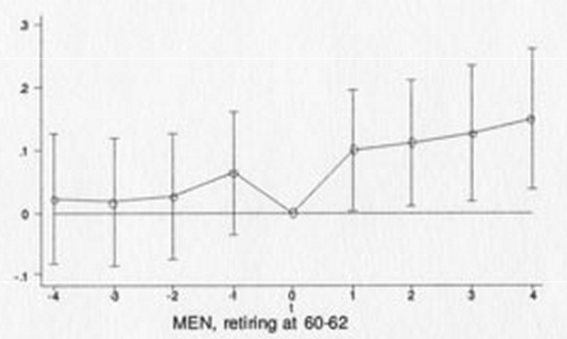

[In men, retiring at ages 60-62 is associated with an increase in self-reported happiness](http://www1.eur.nl/fsw/happiness/hap_cor/top_sub.php?code=R3)

**General Properties**

- The concept of flow and the idea that [having a purpose in one’s life leads to increased satisfaction](http://en.wikipedia.org/wiki/Man's_Search_for_Meaning) both run contra to the idea of this as a trade-off. But, these are mostly interesting insofar as they are exceptions to the general, intuitive rule that humans make day-to-day trade-offs between enjoying themselves and getting things done.
- This trade-off can be “constructed” by considering the interaction of Some Now vs More Later and Loyalty vs Universality, where “savoring” is loyalty to oneself in the short run and “saving” is universality over the long run. However, this is a common enough interaction that it seems canon-worthy.

Particular thanks to Ben Casnocha, Bingo McKenzie, Brian Waterman, Colin Marshall, and Kevin Burke for substantive comments on versions of this.

## References

Akabayashi, H. and Psacharopoulos, G., The Trade‐off Between Child Labour and Human Capital Formation: A Tanzanian Case Study, *The Journal of Development Studies*, vol. **35**, no. 5, pp. 120–40, accessed January 8, 2023, from https://doi.org/10.1080/00220389908422594, June 1, 1999. DOI: 10.1080/00220389908422594

Jones, B. and Rachlin, H., Social discounting, *Psychological Science*, vol. **17**, no. 4, pp. 283–86, April 2006. DOI: 10.1111/j.1467-9280.2006.01699.x

Khan, Q. J. A. and Ghaleb, A. F., A study of prey-predator relations for mammals, *Journal of Theoretical Biology*, vol. **223**, no. 2, pp. 171–78, July 21, 2003. DOI: 10.1016/s0022-5193(03)00084-5

March, J. G., Exploration and Exploitation in Organizational Learning, *Organization Science*, vol. **2**, no. 1, pp. 71–87, accessed January 4, 2023, from https://www.jstor.org/stable/2634940, 1991.

Miller, G. F., Protean Primates: The Evolution of Adaptive Unpredictability in Competition and Courtship, *ELSE Working Papers*, accessed January 3, 2023, from https://ideas.repec.org//p/els/esrcls/046.html, 1997.

Salter, A. J. and Martin, B. R., The Economic Benefits of Publicly Funded Basic Research: A Critical Review, *Research Policy*, vol. **30**, no. 3, pp. 509–32, accessed January 8, 2023, from https://ideas.repec.org//a/eee/respol/v30y2001i3p509-532.html, 2001.

Shackelford, T. K., Schmitt, D. P. and Buss, D. M., Universal Dimensions of Human Mate Preferences, *Personality and Individual Differences*, vol. **39**, pp. 447–58, 2005. DOI: 10.1016/j.paid.2005.01.023

Tononi, G. and Cirelli, C., Sleep function and synaptic homeostasis, *Sleep Medicine Reviews*, vol. **10**, no. 1, pp. 49–62, February 2006. DOI: 10.1016/j.smrv.2005.05.002